# HW4: Stores and products

## Systembolaget stores

The SQLite database `../HW_data/system.sqlite` contains a table of stores and a table containing the number of distinct beverages in each category (`Varugrupp`) some of the stores carry. Connect to the database and send the following queries **using SQL**:

- Query for a table `butik_ombud` containing the number of stores and agents (`butik` and `ombud`) in each county (as given by `Address5`) structured as in

```r
glimpse(butik_ombud)
```

```
## Observations: 43
## Variables: 4
## $ County <chr> NA, "Blekinge län", "Blekinge län", "Dalarnas län", "Da...
## $ City   <chr> "FÅRÖ", "OLOFSTRÖM", "SÖLVESBORG", "IDRE", "FREDRIKSBER...
## $ Number <int> 1, 6, 10, 18, 26, 3, 7, 12, 25, 10, 13, 11, 46, 16, 12,...
## $ Type   <chr> "Ombud", "Butik", "Ombud", "Butik", "Ombud", "Butik", "...
```

- Query for a table `assortment` with structure:

```r
glimpse(assortment)
```

```
## Observations: 7,952
## Variables: 5
## $ Store   <chr> "0102", "0102", "0102", "0102", "0102", "0102", "0102"...
## $ County  <chr> "Stockholms län", "Stockholms län", "Stockholms län", ...
## $ City    <chr> "STOCKHOLM", "STOCKHOLM", "STOCKHOLM", "STOCKHOLM", "S...
## $ Product <chr> "Akvavit och Kryddat brännvin", "Alkoholfritt", "Cider...
## $ Number  <int> 21, 61, 29, 14, 17, 18, 31, 118, 14, 16, 32, 388, 12, ...
```

*You are now done with the SQL part of the homework, the rest should be solved in R code.*

### Mapping stores and agents

#### Choropleth maps

A [choropleth](https://en.wikipedia.org/wiki/Choropleth_map) is a map divided into regions where regions a colored according to the values of some variable. In order to plot a choroplet, we need the region borders as polygons. Polygons for the counties of Sweden can be found in `../HW_data/counties.csv`. Load it by

```r
counties <- read_csv("../HW_data/counties.csv")
```

and examine its structure. You can plot a map by

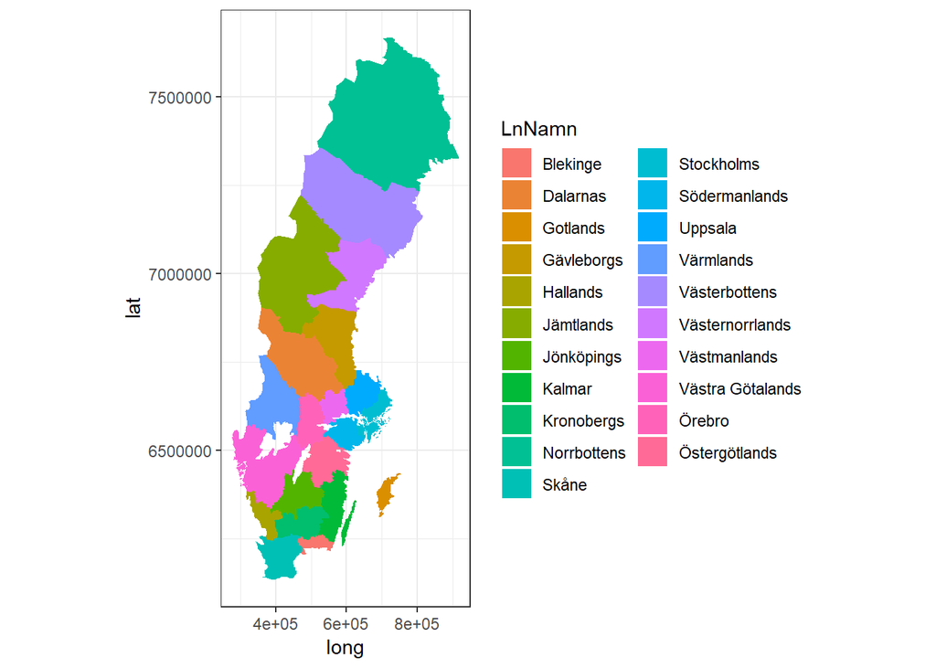

```r
ggplot(counties) + geom_polygon(aes(x = long, y = lat, group = group, fill = LnNamn)) +
    coord_fixed() +
    theme_bw()
```

where fill color is mapped to county name.

- In rural areas stores (`Type == Butik`) tend to be replaced by agents (`Type == Ombud`). Illustrate this by computing the ratio of number of stores to number of agents for each county. Visualise the ratios in a choropleth as above.

### Product patterns

Use the `assortment` table to construct `assortment_wide` with columns `Store`, `County`, `City` and one column for each `Product` containing their *relative proportions* for the store. Computing the proportions is probably most easily done within a `group_by` + `mutate` before using `spread`. The result should look like:

```r
glimpse(assortment_wide)
```

```
## Observations: 442
## Variables: 21
## $ Store                          <chr> "0102", "0104", "0106", "0110",...
## $ County                         <chr> "Stockholms län", "Stockholms l...
## $ City                           <chr> "STOCKHOLM", "STOCKHOLM", "STOC...
## $ `Akvavit och Kryddat brännvin` <dbl> 0.014403292, 0.013626374, 0.015...
## $ Alkoholfritt                   <dbl> 0.04183813, 0.03604396, 0.04721...
## $ Cider                          <dbl> 0.019890261, 0.018021978, 0.020...
## $ Cognac                         <dbl> 0.009602195, 0.010989011, 0.011...
## $ `Gin och Genever`              <dbl> 0.011659808, 0.009230769, 0.010...
## $ `Glögg och Glühwein`           <dbl> 0.012345679, 0.010109890, 0.011...
## $ Likör                          <dbl> 0.021262003, 0.021098901, 0.022...
## $ `Mousserande vin`              <dbl> 0.08093278, 0.07912088, 0.07786...
## $ Portvin                        <dbl> 0.009602195, 0.010109890, 0.010...
## $ Rom                            <dbl> 0.010973937, 0.011428571, 0.009...
## $ Rosévin                        <dbl> 0.02194787, 0.02813187, 0.02820...
## $ `Rött vin`                     <dbl> 0.2661180, 0.2791209, 0.2624157...
## $ Sherry                         <dbl> 0.008230453, 0.007912088, 0.008...
## $ Whisky                         <dbl> 0.058299040, 0.059780220, 0.063...
## $ `Vitt vin`                     <dbl> 0.1714678, 0.1819780, 0.1759657...
## $ `Vodka och Brännvin`           <dbl> 0.009602195, 0.009230769, 0.009...
## $ Öl                             <dbl> 0.14334705, 0.12571429, 0.12875...
## $ Övrigt                         <dbl> 0.08847737, 0.08835165, 0.08645...
```

Extract the rows of `assortment_wide` containing proportions, scale using `scale` and call the result `X`:

- Compute the first two columns of the matrix $U$ in the singular value decomposition of `X` and plot them against eachother. Two stores seem like outliers, identify them (figure out what is special about them if you like).
- The above plot seem to indicate a number of clusters of stores. Apply hierarchical clustering (you choose the linkage) to `X` and divide into 5 or 6 clusters (e.g. using `dist`, `hclust` and `cuttree`). Color the points in the above plot according to the result. Does it agree with the visual clustering?
- Plot the proportions as a heatmap with stores arranged according to the clustering above (cf [last slide](https://mt5013-ht18.github.io/slides/slide8.html#37)). Can you interpret the clusters?
- Apply hierarchical clustering to the transpose of `X` and plot the dendrogram. The result can be interpreted as different “specialisations” among the stores.